# Практичне завдання №1

**Номер за списком:** 1  
**Варіанти:** 1, 6

## Варіант 1

**Завдання:**  
Дано функцію ( f(n) = 5n^2 + 1 ). Знайти асимптотичну складність у ( O )-нотації.

### Розв'язок:

[figure not shown]

## Варіант 6

**Завдання:**  
Довести, що ( f(n) = 150n^2 + 11 = O(n^2) ).

### Розв'язок:

[figure not shown]

### Графік для обох функцій

Нижче наведено графік функцій ( f_1(n) = 5n^2 + 1 ) (Варіант 1), ( f_2(n) = 150n^2 + 11 ) (Варіант 6) та їхніх верхніх меж ( g_1(n) = 6n^2 ) та ( g_2(n) = 151n^2 ):

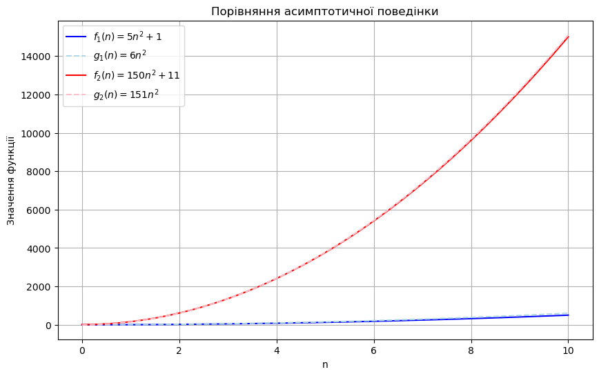

```python
import matplotlib.pyplot as plt
import numpy as np

n = np.linspace(0, 10, 100)
# Варіант 1
f1_n = 5 * n**2 + 1
g1_n = 6 * n**2
# Варіант 6
f2_n = 150 * n**2 + 11
g2_n = 151 * n**2

plt.figure(figsize=(10, 6))
plt.plot(n, f1_n, label='$f_1(n) = 5n^2 + 1$', color='blue')
plt.plot(n, g1_n, label='$g_1(n) = 6n^2$', linestyle='--', color='lightblue')
plt.plot(n, f2_n, label='$f_2(n) = 150n^2 + 11$', color='red')
plt.plot(n, g2_n, label='$g_2(n) = 151n^2$', linestyle='--', color='pink')

plt.xlabel('n')
plt.ylabel('Значення функції')
plt.title('Порівняння асимптотичної поведінки')
plt.legend()
plt.grid()
plt.show()
```

### Висновок

1. **Для функції f₁(n) = 5n² + 1 (Варіант 1):**
   - Асимптотична складність: O(n²)
   - Пояснення: Домінуючий член 5n² визначає квадратичний ріст функції
2. **Для функції f₂(n) = 150n² + 11 (Варіант 6):**
   - Асимптотична складність: O(n²)
   - Пояснення: Незважаючи на великі коефіцієнти, домінуючий член залишається n²
3. **Загальні спостереження:**
   - Обидві функції належать до одного класу складності O(n²)
   - Коефіцієнти та константи не впливають на асимптотичну оцінку
   - Графічна ілюстрація підтверджує однакову природу росту обох функцій
4. **Практичне значення:**
   - Для великих n обидві функції демонструють подібну поведінку
   - Оптимізація алгоритмів з такою складністю має аналогічні підходи

№

Контрольнi питання

Відповідь

1

Що таке асимптотична складність алгоритму?

Це оцінка часу/пам'яті алгоритму при зростанні розміру вхідних даних (𝑛 → ∞).

2

Яким чином визначається 𝑂-нотація і яка її сутність?

𝑂-нотація описує верхню межу складності. Формально: 𝑓(𝑛) = 𝑂(𝑔(𝑛)), якщо існують 𝑐 > 0, 𝑛₀ такі, що 0 ≤ 𝑓(𝑛) ≤ 𝑐𝑔(𝑛) для всіх 𝑛 ≥ 𝑛₀.

3

Які основні правила використання 𝑂-нотації при аналізі алгоритмів?

- Ігнорування констант: 𝑂(2𝑛) = 𝑂(𝑛)
- Вибір домінуючого члена: 𝑂(𝑛² + 𝑛) = 𝑂(𝑛²)
- Правило суми: 𝑂(𝑓(𝑛)) + 𝑂(𝑔(𝑛)) = 𝑂(max(𝑓(𝑛), 𝑔(𝑛)))

4

Що означають вирази 𝑂(1), 𝑂(𝑛), 𝑂(𝑛²) в контексті асимптотичної складності?

- 𝑂(1): Константна складність
- 𝑂(𝑛): Лінійна
- 𝑂(𝑛²): Квадратична

5

Як визначити асимптотичну складність алгоритму за кодом або математичним виразом?

1. Підрахувати кількість операцій у залежності від 𝑛.
2. Використати 𝑂-нотацію для спрощення (відкинути константи, нижчі порядки).
3. Приклад: цикл for(0..n) → 𝑂(𝑛), вкладений цикл for(0..n) { for(0..n) } → 𝑂(𝑛²).